# STAT 497 & IAM 526 Recitation 7

Ozancan Ozdemir

**Forecasting In Time Series**

One of the main objectives in time series analysis is forecasting and there are several methods proposed for this purpose in the literature.

**Simple Exponential Smoothing**

It is a time series forecasting method for univariate data without a trend or seasonality. In other words, s.e.s should only be used for forecasting series that have no trend or seasonality.

The exponential smoother generates a forecast at time t + 1 as follows;

$S_{t+1}=\alpha Y_t + \alpha (1-\alpha)Y_{t-1}+...$ where $\alpha$ is a constant between 0 and 1 called smoothing constant.

**Example 1**

Please load `lynx` dataset. The dataset contains annual numbers of lynx trappings for 1821–1934 in Canada.

```r
data(lynx)
```

```r
head(lynx) #see first 6 observations.
```

```
## [1]  269  321  585  871 1475 2821
```

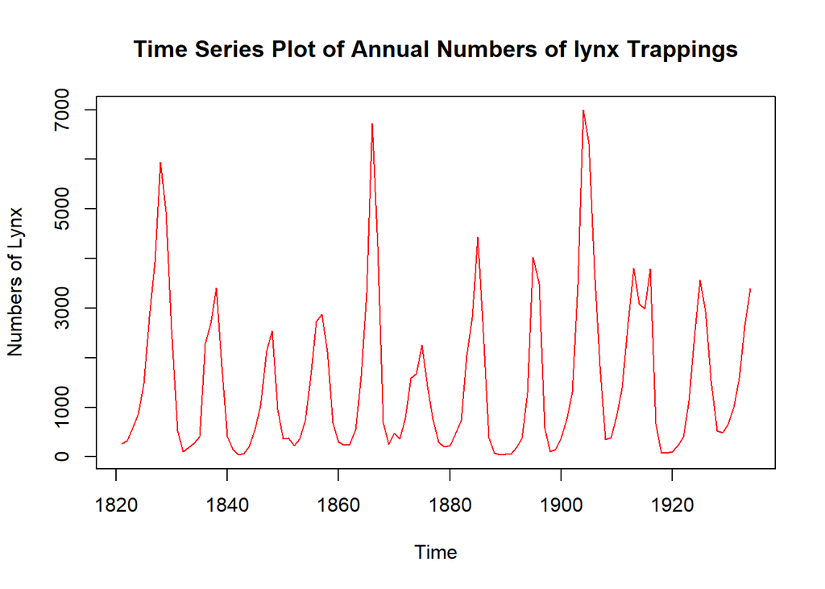

```r
plot(lynx,main="Time Series Plot of Annual Numbers of lynx Trappings",ylab="Numbers of Lynx",col="red")
```

In order to obtain forecast values from simple exponential smoothing, use `ses` function under forecast package.

```
ses(y, h = 10, level = c(80, 95), fan = FALSE,
  initial = c("optimal", "simple"), alpha = NULL, lambda = NULL,
  biasadj = FALSE, x = y, ...)
```

y: a numeric vector or time series of class ts

h: Number of periods for forecasting.

alpha: Value of smoothing parameter for the level. If NULL, it will be estimated.

inital: Method used for selecting initial state values.

```r
index=1:length(lynx)
train=1:round(0.85*length(lynx)) #index of observations in train data
test=index[-train]
```

```r
lynx_train=lynx[train]
lynx_test=lynx[test]
```

```r
library(forecast)
ses_forecast1=ses(lynx_train,h=length(test),alpha = 0.2,initial = "simple")
ses_forecast2=ses(lynx_train,h=length(test),alpha = 0.4,initial = "simple")
ses_forecast3=ses(lynx_train,h=length(test),alpha = 0.6,initial = "simple")
```

```r
summary(ses_forecast1) #to see the summary of the forecasts
```

```
##
## Forecast method: Simple exponential smoothing
##
## Model Information:
## Simple exponential smoothing
##
## Call:
##  ses(y = lynx_train, h = length(test), initial = "simple", alpha = 0.2)
##
##   Smoothing parameters:
##     alpha = 0.2
##
##   Initial states:
##     l = 269
##
##   sigma:  1659.975
## Error measures:
##                   ME     RMSE      MAE       MPE     MAPE     MASE
## Training set 109.353 1659.975 1298.545 -298.4394 342.1871 1.487611
##                   ACF1
## Training set 0.6654261
##
## Forecasts:
##     Point Forecast      Lo 80    Hi 80      Lo 95    Hi 95
##  98       2390.448  263.10438 4517.792  -863.0433 5643.939
##  99       2390.448  220.97467 4559.921  -927.4751 5708.371
## 100       2390.448  179.64766 4601.248  -990.6793 5771.575
## 101       2390.448  139.07913 4641.817 -1052.7235 5833.619
## 102       2390.448   99.22880 4681.667 -1113.6694 5894.565
## 103       2390.448   60.05982 4720.836 -1173.5731 5954.469
## 104       2390.448   21.53840 4759.358 -1232.4866 6013.382
## 105       2390.448  -16.36656 4797.262 -1290.4572 6071.353
## 106       2390.448  -53.68374 4834.580 -1347.5289 6128.425
## 107       2390.448  -90.43966 4871.336 -1403.7422 6184.638
## 108       2390.448 -126.65891 4907.555 -1459.1348 6240.031
## 109       2390.448 -162.36434 4943.260 -1513.7415 6294.637
## 110       2390.448 -197.57721 4978.473 -1567.5950 6348.491
## 111       2390.448 -232.31736 5013.213 -1620.7254 6401.621
## 112       2390.448 -266.60332 5047.499 -1673.1613 6454.057
## 113       2390.448 -300.45248 5081.348 -1724.9291 6505.825
## 114       2390.448 -333.88109 5114.777 -1776.0538 6556.950
```

**Plotting Forecast Values**

First, we draw the plot of train data and fitted values coming from forecast models.

**fitted is a generic function which extracts fitted values from objects returned by modeling functions.**

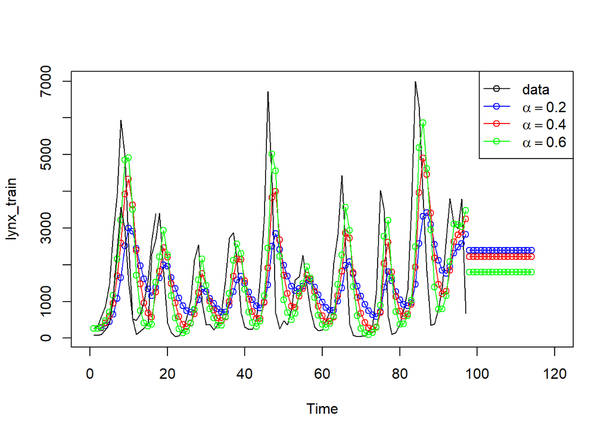

```r
ts.plot(lynx_train,xlim=c(0,120))
lines(fitted(ses_forecast1), col="blue", type="o")
lines(fitted(ses_forecast2), col="red", type="o")
lines(fitted(ses_forecast3), col="green", type="o")
lines(lynx_test)
lines(ses_forecast1$mean, col="blue", type="o")
lines(ses_forecast2$mean, col="red", type="o")
lines(ses_forecast3$mean, col="green", type="o")
legend("topright",lty=1, col=c(1,"blue","red","green"),
       c("data", expression(alpha == 0.2), expression(alpha == 0.4),
         expression(alpha == 0.6)),pch=1)
```

**Compare the methods**

For comparing the forecast methods, we will consider several accuracy measures such as MASE, MAPE, MAE. To obtain such measures, we use `accuracy` function.

```r
accuracy(ses_forecast1) #accuracy of fitted observations
```

```
##                   ME     RMSE      MAE       MPE     MAPE     MASE
## Training set 109.353 1659.975 1298.545 -298.4394 342.1871 1.487611
##                   ACF1
## Training set 0.6654261
```

```r
accuracy(ses_forecast1$mean,lynx_test) #accuracy of forecast observations
```

```
##                 ME     RMSE      MAE      MPE     MAPE
## Test set -1047.742 1576.848 1405.596 -621.441 632.3845
```

```r
accuracy(ses_forecast2) #accuracy of fitted observations
```

```
##                    ME     RMSE      MAE       MPE     MAPE     MASE
## Training set 50.20623 1583.531 1216.292 -239.9424 285.4501 1.393382
##                   ACF1
## Training set 0.6109792
```

```r
accuracy(ses_forecast2$mean,lynx_test) #accuracy of forecast observations
```

```
##                 ME     RMSE      MAE       MPE     MAPE
## Test set -874.2957 1467.337 1334.177 -569.0947 583.5122
```

```r
accuracy(ses_forecast3) #accuracy of fitted observations
```

```
##                    ME     RMSE      MAE       MPE     MAPE    MASE
## Training set 26.28884 1462.913 1083.704 -156.7634 204.6454 1.24149
##                   ACF1
## Training set 0.5397826
```

```r
accuracy(ses_forecast3$mean,lynx_test) #accuracy of forecast observations
```

```
##                 ME     RMSE      MAE       MPE     MAPE
## Test set -456.3045 1263.685 1162.063 -442.9442 465.7341
```

Select the forecasting method having the smallest comparison criteria selected. Thus, for this example, SES with $\alpha=0.6$ produce the better forecast values compared to other techniques.

**Double Exponential Smoothing / Holt’s Exponential Smoothing**

For series that contain a trend, we can use double exponential smoothing, also called Holt’s linear trend model. In double exponential smoothing, the local trend is estimated from the data and is updated as more data becomes available.

**SES+Trend=DES**

```
holt(y, h = 10, damped = FALSE, level = c(80, 95), fan = FALSE,
  initial = c("optimal", "simple"), exponential = FALSE,
  alpha = NULL, beta = NULL, phi = NULL, lambda = NULL,
  biasadj = FALSE, x = y, ...)
```

damped :If TRUE, use a damped trend.

exponential :If TRUE, an exponential trend is fitted. Otherwise, the trend is (locally) linear.

**Example 2**

Please load `elecsales` dataset being available in `fpp` package. The dataset can be described as annual electricity sales for South Australia in GWh from 1989 to 2008.

```r
library(fpp)
data(elecsales)
elecsales
```

```
## Time Series:
## Start = 1989
## End = 2008
## Frequency = 1
##  [1] 2354.34 2379.71 2318.52 2468.99 2386.09 2569.47 2575.72 2762.72
##  [9] 2844.50 3000.70 3108.10 3357.50 3075.70 3180.60 3221.60 3176.20
## [17] 3430.60 3527.48 3637.89 3655.00
```

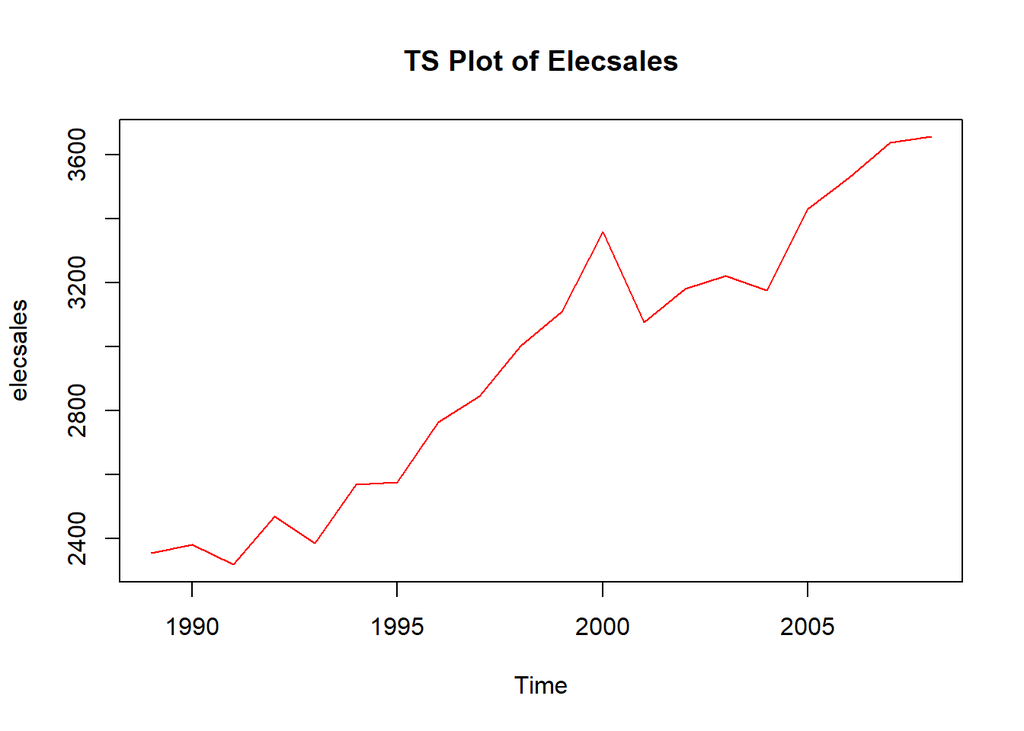

```r
plot(elecsales,main="TS Plot of Elecsales",col="red")
```

Divide your datasets. Now, I will consider first 16 observations as the train data.

```r
e_train=ts(elecsales[1:16],start=1989)
e_test=ts(elecsales[17:20],start=2005)
```

```r
fit1 <- ses(e_train,h=4) #☻number of periods for forecasting
fit2 <- holt(e_train,h=4)
fit3 <- holt(e_train,exponential=TRUE,h=4)
fit4 <- holt(e_train,damped=TRUE,h=4)
```

```r
accuracy(fit1,e_test)
```

```
##                     ME     RMSE      MAE       MPE      MAPE      MASE
## Training set  57.92674 135.6916 110.4401  1.985782  3.847001 0.9388821
## Test set     382.11471 392.7182 382.1147 10.666890 10.666890 3.2484645
##                    ACF1 Theil's U
## Training set -0.3090196        NA
## Test set      0.2721152  4.946741
```

```r
accuracy(fit2,e_test)
```

```
##                     ME      RMSE      MAE        MPE     MAPE      MASE
## Training set  1.123566 114.94638 85.49246 -0.1238647 3.021798 0.7267954
## Test set     45.512782  51.60533 45.51278  1.2689038 1.268904 0.3869169
##                    ACF1 Theil's U
## Training set  0.2983581        NA
## Test set     -0.2548562 0.6772125
```

```r
accuracy(fit3,e_test)
```

```
##                      ME      RMSE      MAE         MPE     MAPE      MASE
## Training set   3.433914 119.45910 89.46911 -0.03607011 3.107674 0.7606021
## Test set     -39.468132  49.44752 39.46813 -1.10114421 1.101144 0.3355297
##                    ACF1 Theil's U
## Training set  0.3204227        NA
## Test set     -0.2793208 0.6092683
```

```r
accuracy(fit4,e_test)
```

```
##                      ME     RMSE       MAE         MPE     MAPE      MASE
## Training set   1.419083 118.2185  97.47513 -0.05546485 3.452561 0.8286635
## Test set     226.608708 230.7951 226.60871  6.33429882 6.334299 1.9264643
##                     ACF1 Theil's U
## Training set -0.04384686        NA
## Test set      0.19620082  2.878061
```

Since we made both train and test set as ts object, accuracy function give comparison measure values for both training and test set when we include test set in accuracy function.

**Plotting the forecast values and test set**

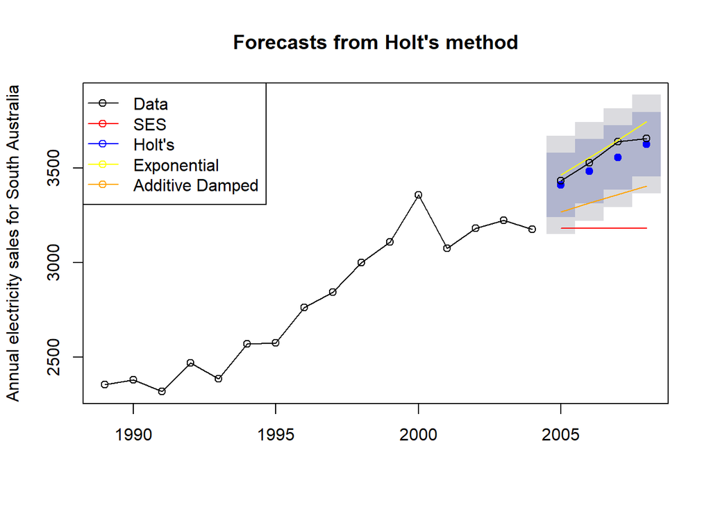

```r
plot(fit2, type="o", ylab="Annual electricity sales for South Australia", flwd=1)
lines(e_test,type="o")
lines(fit1$mean,col="red")
lines(fit3$mean,col="yellow")
lines(fit4$mean,col="orange")

legend("topleft", lty=1, pch=1, col=c(1,"red","blue","yellow","orange"), c("Data","SES","Holt's","Exponential", "Additive Damped"))
```

**Holt’s Winter Exponential Smoothing**

For series that contain both trend and seasonality, the Holt- Winter’s exponential smoothing method can be used. This is a further extension of double exponential smoothing, where the k-step-ahead forecast also takes into account the season at period t + k. As for trend, there exist formulations for additive and multiplicative seasonality. In multiplicative seasonality, values on different seasons differ by percentage amounts, whereas in additive seasonality, they differ by a fixed amount.

```
ets(y, model = "ZZZ", damped = NULL, alpha = NULL, beta = NULL,
  gamma = NULL, phi = NULL, additive.only = FALSE, lambda = NULL,
  biasadj = FALSE, lower = c(rep(1e-04, 3), 0.8),
  upper = c(rep(0.9999, 3), 0.98), opt.crit = c("lik", "amse", "mse",
  "sigma", "mae"), nmse = 3, bounds = c("both", "usual", "admissible"),
  ic = c("aicc", "aic", "bic"), restrict = TRUE,
  allow.multiplicative.trend = FALSE, use.initial.values = FALSE,
  na.action = c("na.contiguous", "na.interp", "na.fail"), ...)
```

y: a numeric vector or time series of class ts

model: Usually a three-character string identifying method using the framework terminology of Hyndman et al. (2002) and Hyndman et al. (2008). The first letter denotes the error type (“A”, “M” or “Z”); the second letter denotes the trend type (“N”,“A”,“M” or “Z”); and the third letter denotes the season type (“N”,“A”,“M” or “Z”). In all cases, “N”=none, “A”=additive, “M”=multiplicative and “Z”=automatically selected. So, for example, “ANN” is simple exponential smoothing with additive errors, “MAM” is multiplicative Holt-Winters’ method with multiplicative errors, and so on.

**Example 3**

Consider `cafe` data set containing the total quarterly expenditure on cafes, restaurants and takeway food services in Australia (1982:Q2-2010:Q4).

```r
library(fpp)
```

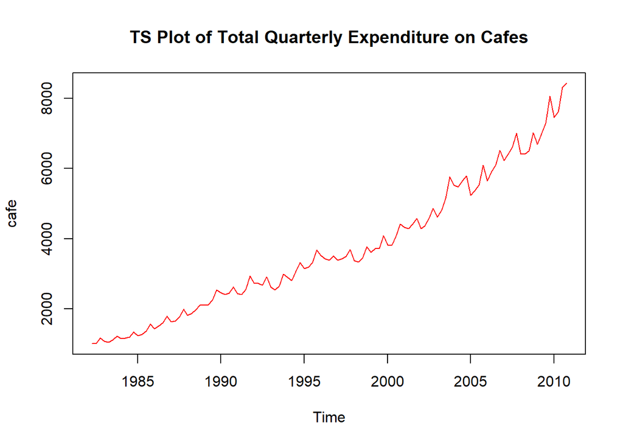

```r
plot(cafe,main="TS Plot of Total Quarterly Expenditure on Cafes",col="red")
```

```r
cafe_train=ts(cafe[1:107],start=c(1982,2),frequency = 4) #I use start=c(1982,2) since my observations starts at 2nd quarter.
cafe_test=ts(cafe[108:115],start=2009,frequency = 4)
```

```r
fit1=ets(cafe_train,model="ZZZ") #The algorithm automatically decides type of the components.
```

forecast is a generic function for forecasting from time series or time series models.

```r
fr1=forecast(fit1,h=8) #h represents the forecast horizons. i,e I have 8 forecast observations.
fr1
```

```
##         Point Forecast    Lo 80    Hi 80    Lo 95    Hi 95
## 2009 Q1       6547.708 6308.789 6786.626 6182.313 6913.102
## 2009 Q2       6534.086 6180.221 6887.951 5992.896 7075.276
## 2009 Q3       6719.424 6252.675 7186.174 6005.592 7433.257
## 2009 Q4       7270.875 6661.374 7880.377 6338.723 8203.028
## 2010 Q1       6775.270 6112.890 7437.649 5762.248 7788.292
## 2010 Q2       6759.218 6005.506 7512.931 5606.515 7911.922
## 2010 Q3       6948.966 6079.000 7818.931 5618.468 8279.463
## 2010 Q4       7517.152 6473.062 8561.242 5920.354 9113.949
```

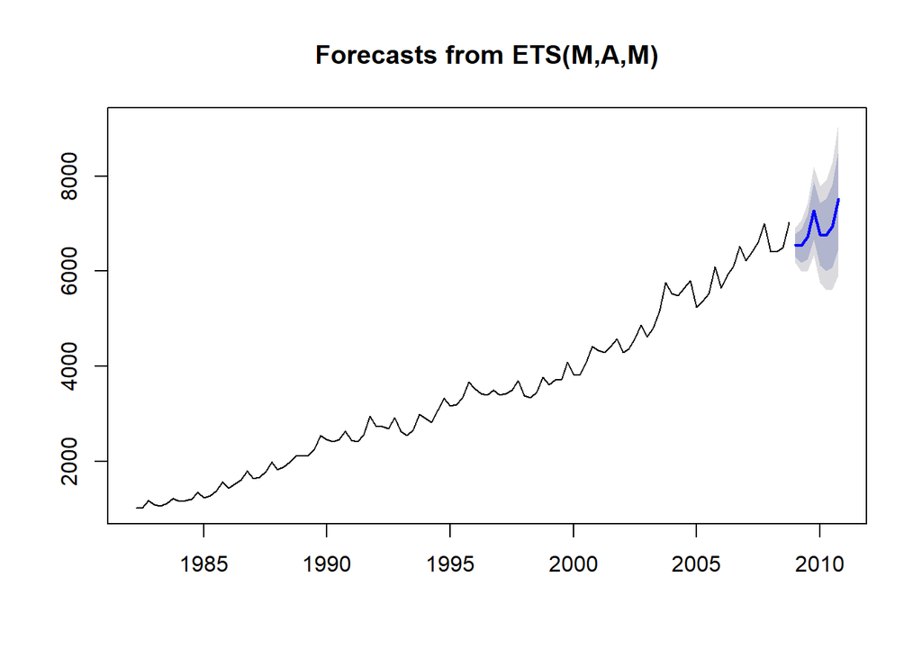

```r
plot(fr1)
```

When you draw the plot of forecast values obtained from the forecast function, the forecast plot shows both forecast observations and prediction intervals on the same plot. We aim to find the method having narrower interval compared to others.

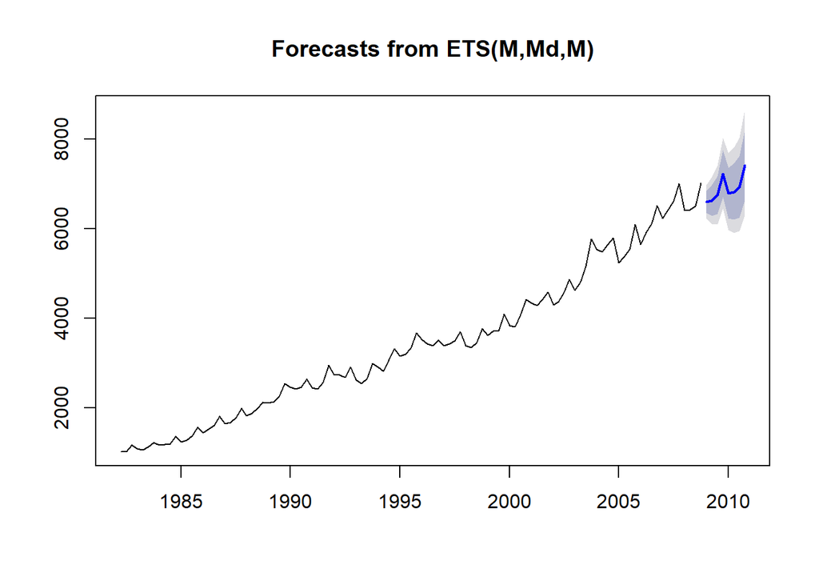

```r
fit2=ets(cafe_train,model='MMM')
fr2=forecast(fit2)
plot(forecast(fit2))
```

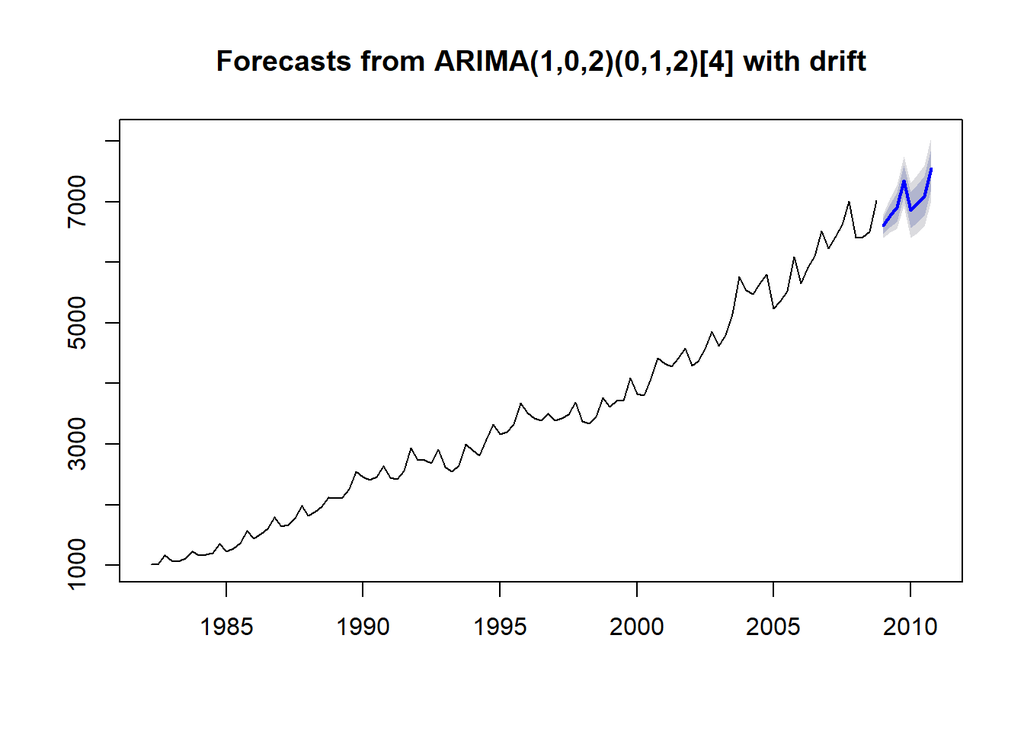

```r
fit3=auto.arima(cafe_train)
fr3=forecast(fit3)
plot(forecast(fit3))
```

Compare the models with respect to comparison criterias.

```r
accuracy(fr1,cafe_test)
```

```
##                      ME      RMSE       MAE        MPE     MAPE      MASE
## Training set   1.267474  98.48168  75.13622 0.02757551 2.289810 0.3089039
## Test set     721.512643 795.92855 721.51264 9.23496175 9.234962 2.9663198
##                   ACF1 Theil's U
## Training set 0.1313021        NA
## Test set     0.4153489  1.699262
```

```r
accuracy(fr2,cafe_test)
```

```
##                     ME     RMSE       MAE       MPE     MAPE     MASE
## Training set  12.51767 103.0519  76.47988 0.2520897 2.260717 0.314428
## Test set     714.07554 805.4848 714.07554 9.0861556 9.086156 2.935744
##                   ACF1 Theil's U
## Training set 0.2001439        NA
## Test set     0.4514130  1.712758
```

```r
accuracy(fr3,cafe_test)
```

```
##                       ME      RMSE       MAE        MPE     MAPE      MASE
## Training set   0.8509772  94.59281  72.13944 -0.2968346 2.245243 0.2965833
## Test set     593.3934438 684.59175 593.39344  7.5202338 7.520234 2.4395895
##                    ACF1 Theil's U
## Training set 0.01069538        NA
## Test set     0.47794221  1.448062
```

**Example 4**

- $SARIMA(1,1,1)(1,1,1)_{12}$.
- $SARIMA(0,1,1)(0,1,1)_{12}$.

```r
prod=ts(read.csv("prod.csv",header=F),start=c(1965,12),frequency=12)
#start=c(year,month)
```

After reading the dataset, to compare the methods, we divide the dataset into two parts.

```r
prod_train=ts(prod[1:96],start=c(1965,12),frequency=12)
```

```r
prod_test=ts(prod[97:108],start=c(1973,12),frequency = 12)
```

Now, we applied Box-Cox transformation to trained dataset.

```r
lambda=BoxCox.lambda(prod_train)
lambda
```

```
## [1] -0.2193545
```

Now, we apply BoxCox Transformation to trained data set for $\lambda= -0.2193545$.

```r
prod_train_transformed=BoxCox(prod_train,lambda = lambda)
```

Now, we fit the models that we identified last recitation.

```r
sfit1=Arima(prod_train_transformed, order = c(1, 1, 1), seasonal = list(order=c(1, 1, 1),period=12))
```

```r
sfit2=Arima(prod_train_transformed, order = c(0, 1, 1), seasonal = list(order=c(0, 1, 1),period=12))
```

There are several ways of getting forecast values from fitted ARIMA models.

```r
#first way of getting forecast
ff=forecast(sfit1,h=12)
ff$mean
```

```
##           Jan      Feb      Mar      Apr      May      Jun      Jul
## 1973
## 1974 3.125930 3.134708 3.137706 3.140982 3.136276 3.131660 3.034690
##           Aug      Sep      Oct      Nov      Dec
## 1973                                     3.121501
## 1974 3.134841 3.134292 3.145435 3.136979
```

```r
# another way of getting forecast
ff1=predict(sfit1,n.ahead=12)
ff1$pred
```

```
##           Jan      Feb      Mar      Apr      May      Jun      Jul
## 1973
## 1974 3.125930 3.134708 3.137706 3.140982 3.136276 3.131660 3.034690
##           Aug      Sep      Oct      Nov      Dec
## 1973                                     3.121501
## 1974 3.134841 3.134292 3.145435 3.136979
```

```r
#or
library(astsa)
```

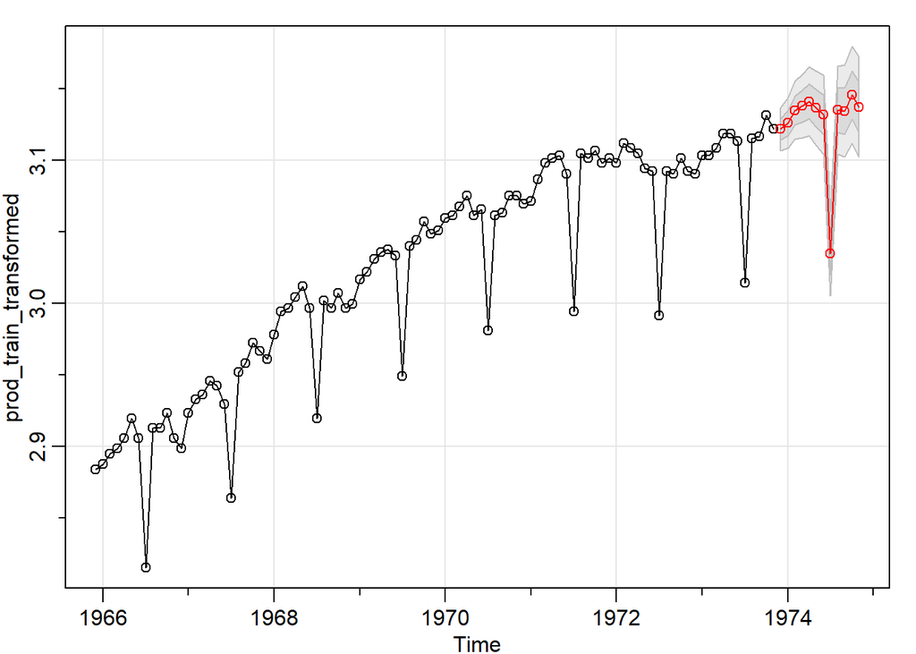

```r
ff2=sarima.for(prod_train_transformed, 12, p=1, d=1, q=1, P = 1, D = 1, Q = 1, S = 12, no.constant = FALSE)
```

```r
ff2$pred
```

```
##           Jan      Feb      Mar      Apr      May      Jun      Jul
## 1973
## 1974 3.125930 3.134708 3.137706 3.140982 3.136276 3.131660 3.034690
##           Aug      Sep      Oct      Nov      Dec
## 1973                                     3.121501
## 1974 3.134841 3.134292 3.145435 3.136979
```

`sarima.for` function under astsa library produces both forecast values and forecast plot with prediction intervals.

As you see above examples, there are several ways to obtain forecast values from fitted (s)arima models. To go further, select the one way (say forecast function.)

```r
ff$mean #forecast values from first fit.
```

```
##           Jan      Feb      Mar      Apr      May      Jun      Jul
## 1973
## 1974 3.125930 3.134708 3.137706 3.140982 3.136276 3.131660 3.034690
##           Aug      Sep      Oct      Nov      Dec
## 1973                                     3.121501
## 1974 3.134841 3.134292 3.145435 3.136979
```

```r
ff_2=forecast(sfit2,h=12)
ff_2$mean
```

```
##           Jan      Feb      Mar      Apr      May      Jun      Jul
## 1973
## 1974 3.128533 3.135944 3.140218 3.145461 3.142796 3.137212 3.043398
##           Aug      Sep      Oct      Nov      Dec
## 1973                                     3.120827
## 1974 3.141329 3.141441 3.153015 3.144590
```

Let me remind you last 6 observation of the train dataset.

```r
tail(prod_train)
```

```
##      Jun Jul Aug Sep Oct Nov
## 1973 188 139 189 190 199 193
```

As you can observed that after applying BoxCox transformation, the scale of the dataset is changed. That’s why you need to go to original series after obtaining the forecast values from the transformed dataset.

```
InvBoxCox(x, lambda, biasadj = FALSE, fvar = NULL)
```

The function calculates the inverse Box-Cox transformation of a variable. Requires arguments x and lambda.

```r
ff_original=InvBoxCox(ff$mean,lambda=lambda)
ff_original
```

```
##           Jan      Feb      Mar      Apr      May      Jun      Jul
## 1973
## 1974 195.6319 201.1892 203.1314 205.2800 202.2025 199.2382 147.6459
##           Aug      Sep      Oct      Nov      Dec
## 1973                                     192.8984
## 1974 201.2752 200.9219 208.2451 202.6583
```

```r
ff_2_original=InvBoxCox(ff_2$mean,lambda=lambda)
ff_2_original
```

```
##           Jan      Feb      Mar      Apr      May      Jun      Jul
## 1973
## 1974 197.2603 201.9877 204.7763 208.2627 206.4815 202.8099 151.5532
##           Aug      Sep      Oct      Nov      Dec
## 1973                                     192.4867
## 1974 205.5094 205.5830 213.4132 207.6785
```

Now, we can calculate accuracy measures and draw the plot of the forecast values.

```r
accuracy(ff_original,prod_test)
```

```
##                ME     RMSE      MAE      MPE     MAPE      ACF1 Theil's U
## Test set 10.47349 11.81749 10.47349 5.120116 5.120116 0.5709083 0.5679145
```

```r
accuracy(ff_2_original,prod_test)
```

```
##                ME     RMSE      MAE      MPE     MAPE      ACF1 Theil's U
## Test set 7.349784 8.451647 7.349784 3.623424 3.623424 0.4690767 0.4068649
```

Now, we draw the plot of the time series, forecasts and prediction intervals on the same plot using the following codes.

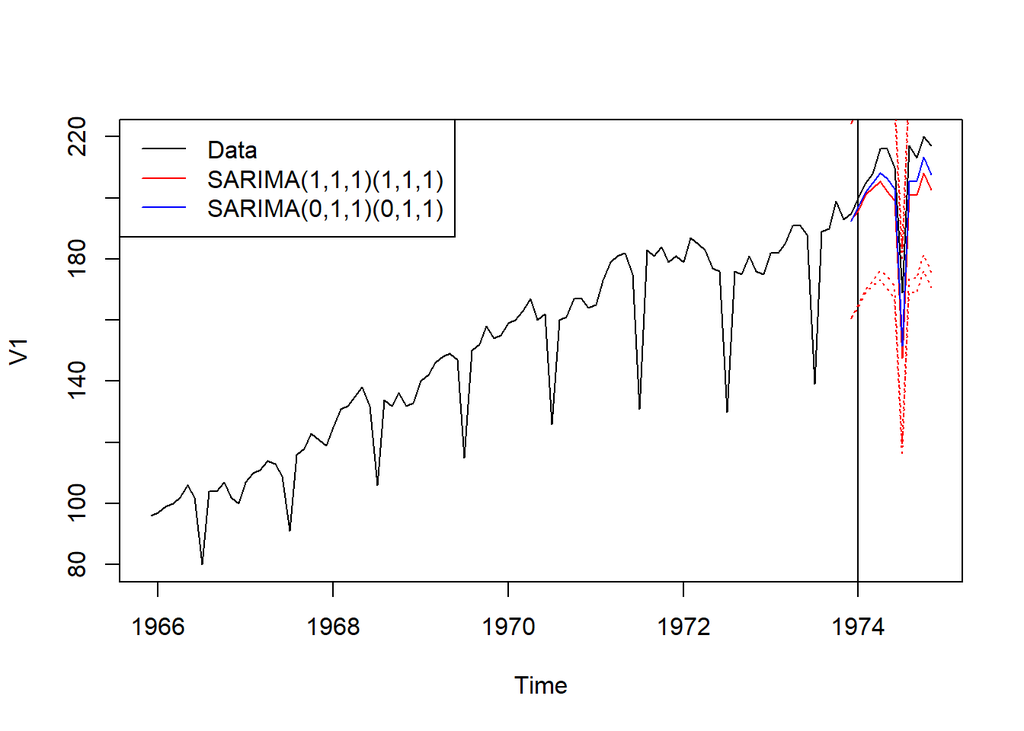

```r
plot(prod)
abline(v=1974)#show where forecast starts
lines(ff_original,col="red") #forecast values coming from fit 1
#now we add prediction intervals for the first fitted models.
lines(ff_original-(2*(sqrt(var(ff_original)))),col="red",lty=3)
lines(ff_original+(2*(sqrt(var(ff_original)))),col="red",lty=3)
#now we add forecast values obtained from the fit 2
lines(ff_2_original,col="blue")
#now we add prediction intervals for the second fitted models.
lines(ff_2_original-(2*(sqrt(var(ff_original)))),col="red",lty=3)
lines(ff_2_original+(2*(sqrt(var(ff_original)))),col="red",lty=3)

legend("topleft",lty=1, col=c("black","red","blue"),c("Data","SARIMA(1,1,1)(1,1,1)","SARIMA(0,1,1)(0,1,1)"))
```

**IN YOUR PROJECT, YOU CAN USE SEVERAL PACKAGES TO DRAW DIFFERENT PLOTS.**

**Question**

```r
bond=ts(read.table("annual_bond_yield.txt"),start=1900,frequency = 1)
```

1. Keep last 5 observations out of the analysis and create both train and test data.

```r
train=ts(bond[1:364],start=1900,frequency = 1) #create the train data
test=ts(bond[365:369],start=2264,frequency = 1)
```

2. Apply the Box-Cox transformation on your train data if it is necessary by generating lambda value.

```r
library(forecast)
lambda=BoxCox.lambda(train)
lambda
```

```
## [1] 1.999924
```

Since the generated lambda value for the train dataset is almost 2. Therefore, we should apply boxcox transformation since lambda value is **different than 1**

```r
train_t=BoxCox(train,lambda)
```

3. In the previous recitation we suggest the following model for the series.

$ARIMA (0,2,1)$

$ARIMA (0,2,2)$

$ARIMA (3,2,1)$

Fit the models and obtain the forecasts.

```r
library(forecast)
fit1<-Arima(train_t,order = c(0, 2, 1))
f1=forecast(fit1,h=5)
```

```r
fit2<-Arima(train_t,order = c(0, 2, 2))
f2=forecast(fit2,h=5)
```

```r
fit3<-Arima(train_t,order = c(3, 2, 1))
f3=forecast(fit3,h=5)
```

4. Use ets() function and obtain forecasts using exponential smoothing method.

```r
f4=forecast(ets(train_t,model="ZZZ"))
```

5. If you apply BoxCox transformation in the 2nd question, go back to original unit. Then calculate the accuarcy measures all methods.

```r
ff1_o=InvBoxCox(f1$mean,lambda )
ff2_o=InvBoxCox(f2$mean,lambda )
ff3_o=InvBoxCox(f3$mean,lambda )
ff4_o=InvBoxCox(f4$mean,lambda )
```

```r
accuracy(ff1_o,test)
```

```
##                ME     RMSE      MAE      MPE     MAPE       ACF1 Theil's U
## Test set 23.18508 23.92436 23.18508 6.597039 6.597039 0.05450695  4.233738
```

```r
accuracy(ff2_o,test)
```

```
##                ME    RMSE      MAE      MPE     MAPE       ACF1 Theil's U
## Test set 24.02095 24.7266 24.02095 6.835736 6.835736 0.05143303  4.366368
```

```r
accuracy(ff3_o,test)
```

```
##                ME     RMSE      MAE     MPE    MAPE         ACF1 Theil's U
## Test set 24.89333 25.52648 24.89333 7.08531 7.08531 -0.005664375  4.488301
```

```r
accuracy(ff4_o,test)
```

```
##                ME     RMSE      MAE      MPE     MAPE       ACF1 Theil's U
## Test set 19.39919 19.89393 19.39919 5.521361 5.521361 -0.1251029  3.488338
```

We can say that ETS outperfoms the other method according to MAPE.

6. Draw the plot of the time series, forecasts and prediction intervals on the same plot.

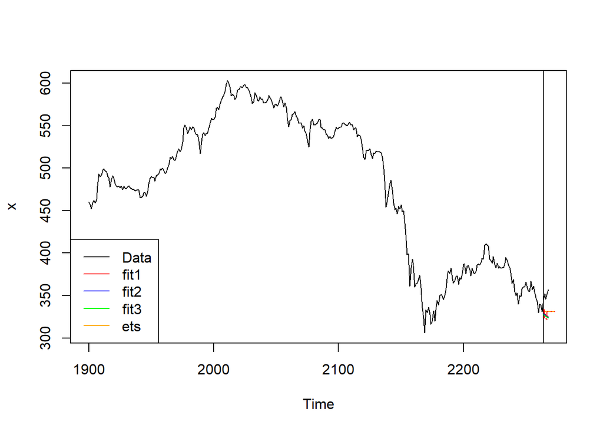

```r
plot(bond)
abline(v=2264)#show where forecast starts
lines(ff1_o,col="red") #forecast values coming from fit 1
#now we add prediction intervals for the first fitted models.
lines(ff1_o-(2*(sqrt(var(ff1_o)))),col="red",lty=3)
lines(ff1_o+(2*(sqrt(var(ff1_o)))),col="red",lty=3)
#now we add forecast values obtained from the fit 2
lines(ff2_o,col="blue")
#now we add prediction intervals for the second fitted models.
lines(ff2_o-(2*(sqrt(var(ff2_o)))),col="red",lty=3)
lines(ff2_o+(2*(sqrt(var(ff2_o)))),col="red",lty=3)

#now we add forecast values obtained from the fit 2
lines(ff3_o,col="green")
#now we add prediction intervals for the second fitted models.
lines(ff3_o-(2*(sqrt(var(ff3_o)))),col="red",lty=3)
lines(ff3_o+(2*(sqrt(var(ff3_o)))),col="red",lty=3)

#now we add forecast values obtained from the fit 2
lines(ff4_o,col="orange")
#now we add prediction intervals for the second fitted models.
lines(ff4_o-(2*(sqrt(var(ff4_o)))),col="red",lty=3)
lines(ff4_o+(2*(sqrt(var(ff4_o)))),col="red",lty=3)

legend("bottomleft",lty=1, col=c("black","red","blue","green","orange"),c("Data","fit1","fit2","fit3","ets"))
```